# Análise da rede de relatorias na CCJC em 2019

29/09/2019

# Apresentação

Este documento descreve alguns padrões na rede partidária de relatorias na CCJC no ano de 2019 na Câmara. Para a análise, o histórico de todas as proposições com movimentação na CCJC em 2019 foi extraído da nova [API de Dados Abertos da Câmara](https://dadosabertos.camara.leg.br/).[^1].

122 Deputados(as) Federais foram designados(as) para a relatoria de 1250 proposições (considerando apenas PEC, PL, PLP e MPV, seguindo a seleção que normalmente fazemos no OLB) únicas, em um total de 1363 designações de relator feitas na CCJC em 2019. As demais seções do documento examinam detalhadamente essa rede.

# A rede de relatorias

Quando uma proposição recebe um relator na CCJC, temos duas informações relevantes para montar uma rede: a filiação partidária do autor da proposição; e a filiação do seu relator. Quando uma proposição têm mais de um relator, essa relação é desdobrada em mais conexões. Se o Poder Executivo ou outros atores iniciaram uma dada proposição, seu partido é considerado como *Outros*.

Esses dados formam uma rede direcional de relatorias. O gráfico abaixo exibe uma visualização dessa rede. Pontos (i.e., vértices) indicam um dado partido, e as linhas (i.e., arestas) indicam uma conexão entre dois partidos (e.g., uma proposição cujo autor é do PT recebe um relator do PSB). Linhas mais sólidas indicam mais conexões, e o tamanho dos pontos indica a centralidade de arestas recebidas (i.e., o número de relatorias recebida pelo partido, *in-centrality*). Por essa métrica, o PSL é disparado o ator mais central da rede. Outros testes que fiz mostram que essa rede, além disso. é estática (i.e., esse padrão é mais ou menos o mesmo durante todo o ano).

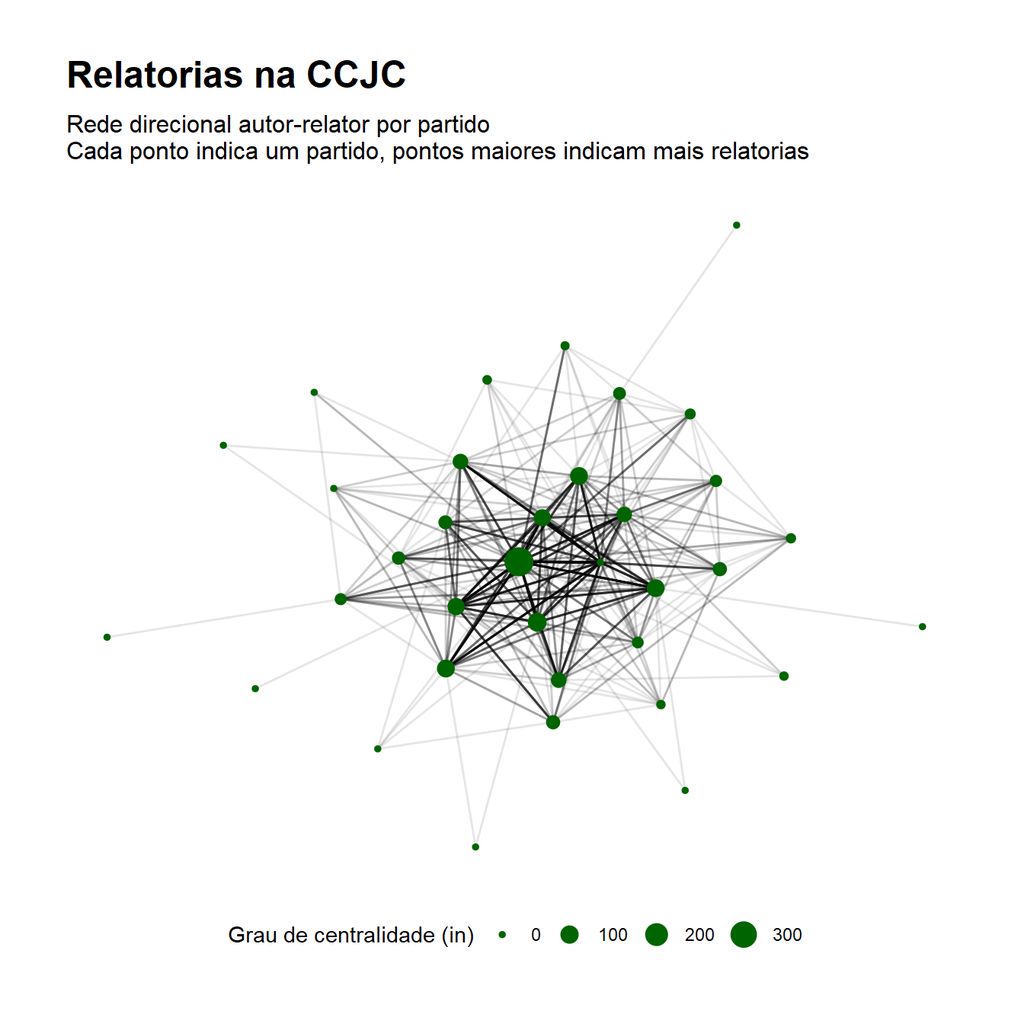

As tabelas abaixo reportam o número de partidos com maior *out-centrality* (i.e., com mais proposições apresentadas cujos relatores na CCJC foram designados em 2019) e com maior *in-centrality* (i.e., com mais relatorias).

Proposições apresentadas com relator designado na CCJC em 2019 (10 mais)

| Partido | Out-Centrality |
| --- | --- |
| Outros | 319 |
| DEM | 147 |
| MDB | 110 |
| PT | 109 |
| PP | 106 |
| PDT | 68 |
| PSDB | 67 |
| PSD | 59 |
| PSL | 52 |
| REPUBLICANOS | 49 |

Relatorias recebidas na CCJC por partido em 2019 (10 mais)

| Partido | In-Centrality |
| --- | --- |
| PSL | 380 |
| PSD | 110 |
| PDT | 93 |
| REPUBLICANOS | 92 |
| PP | 91 |
| DEM | 83 |
| MDB | 79 |
| PODE | 57 |
| PSDB | 56 |
| PT | 55 |

# Proposições apresentadas e relatadas

O PSL recebeu muito mais relatorias do que apresentou proposições relatadas por outros partidos na CCJC em 2019. Outros partidos, como o DEM e o PT, apresentaram mais do que relataram.O gráfico abaixo sintetiza essa informação, com o eixo X indicando o número de proposições apresentadas pelo partido que receberam designação de relatoria em 2019; e, no eixo Y, o número de relatorias recebidas no mesmo período. Quando um partido está acima da linha diagonal tracejada, ele recebeu mais relatorias do que apresentou projetos.

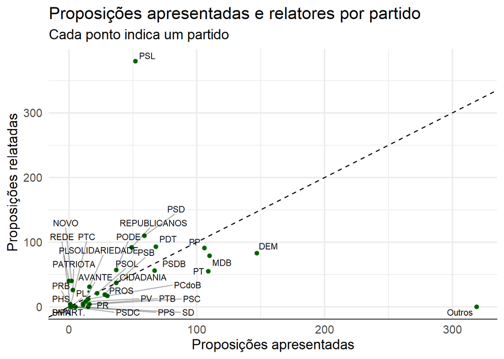

# Relatorias do PSL

Relatorias do PSL por filiação partidária do autor da proposição

| Partido do autor | Proposições relatadas pelo PSL | % |
| --- | --- | --- |
| Outros | 78 | 24.5 |
| DEM | 47 | 32.0 |
| PSL | 37 | 71.2 |
| MDB | 34 | 30.9 |
| PP | 30 | 28.3 |
| PSD | 20 | 33.9 |
| REPUBLICANOS | 20 | 40.8 |
| PT | 18 | 16.5 |
| PSDB | 16 | 23.9 |
| PDT | 12 | 17.6 |
| PODE | 10 | 27.0 |
| CIDADANIA | 9 | 32.1 |
| PCdoB | 8 | 53.3 |
| PROS | 7 | 23.3 |
| PSC | 7 | 63.6 |
| PV | 4 | 30.8 |
| PPS | 3 | 60.0 |
| PR | 3 | 20.0 |
| PSB | 3 | 8.1 |
| PTB | 3 | 18.8 |
| SOLIDARIEDADE | 3 | 18.8 |
| AVANTE | 2 | 18.2 |
| PATRIOTA | 1 | 33.3 |
| PHS | 1 | 100.0 |
| PSDC | 1 | 50.0 |
| PSOL | 1 | 4.5 |
| REDE | 1 | 100.0 |
| SD | 1 | 20.0 |

# Quem relata as posições de partidos da oposição?

O gráfico abaixo reporta a quantia de proposições apresentadas por PT, PSOL, PSB, PDT e PCdoB relatas pelos partidos indicados no eixo Y. Como é possível observar, o PSL relata um número considerável de iniciativas do PT e do PDT, embora ambos os partidos também retenham um grande número de relatorias nesses casos.

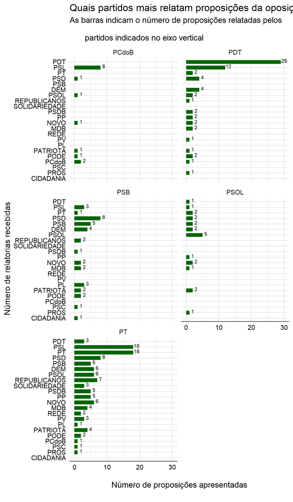

[^1]: Usei o pacote em `R` que criei para o OLB na coleta: https://fmeireles.com/pacote/